# Selection, fitness and dominance

Population Genetics Practical 7: Allele-frequency change and finite-population outcomes

## Learning objectives

Specify a selection life cycle; calculate genotype weighting and allele-frequency change; compare fitness dominance models; identify a heterozygote-advantage equilibrium; and distinguish a selected allele’s deterministic trajectory from its finite-population fate.

Continue from Practical 6. Follow the slides on fitness, the general selection model and balancing selection.

Use base R and hypothetical parameters. A/a are allele labels; dominance here concerns **fitness**, not necessarily dominance for a measured trait such as body weight. No simulated trajectory is presented as a biological finding.

## 1. State the life cycle

Begin with random union of gametes at A frequency $p$, giving zygote proportions $p^2,2pq,q^2$. Apply genotype fitness weights $w_{AA},w_{Aa},w_{aa}$ to their reproductive contributions. Count A in the selected pool, then form the next zygotes by random mating. There is no mutation or migration.

$$\bar w=p^2w_{AA}+2pqw_{Aa}+q^2w_{aa},$$
$$p'=\frac{p^2w_{AA}+pqw_{Aa}}{\bar w}.$$

Weights describe relative contribution under this model. If the mean contribution is zero, a next-generation pool is undefined. Multiplying every fitness by the same positive constant leaves the allele-frequency recursion unchanged.

**Show R code**

```r
selection_step <- function(p,fitness) {
  stopifnot(length(p)==1L,is.finite(p),p>=0,p<=1,
            identical(names(fitness),c("AA","Aa","aa")),
            all(is.finite(fitness)),all(fitness>=0))
  zygotes <- c(AA=p^2,Aa=2*p*(1-p),aa=(1-p)^2)
  contribution <- zygotes*fitness
  mean_fitness <- sum(contribution)
  stopifnot(mean_fitness>0)
  selected <- contribution/mean_fitness
  list(p_next=unname(selected["AA"]+selected["Aa"]/2),
       mean_fitness=mean_fitness,zygotes=zygotes,selected=selected)
}
fitness <- c(AA=1.2,Aa=1.1,aa=1)
step <- selection_step(.5,fitness)
knitr::kable(rbind(Before_selection=step$zygotes,
                   Selected_contributions=step$selected),digits=4)
```

|  | AA | Aa | aa |
| --- | --- | --- | --- |
| Before_selection | 0.2500 | 0.5 | 0.2500 |
| Selected_contributions | 0.2727 | 0.5 | 0.2273 |

**Show R code**

```r
step$p_next
```

```
[1] 0.5227273
```

**Show R code**

```r
stopifnot(abs(step$p_next-23/44)<1e-12,
          abs(selection_step(.3,c(AA=1,Aa=1,aa=1))$p_next-.3)<1e-12,
          abs(selection_step(.5,10*fitness)$p_next-step$p_next)<1e-12)
```

**Question 1.** Are the selected contribution proportions automatically HWE proportions at the new frequency?

**Suggested answer**

No. Genotype-dependent weighting changes the selected pool’s proportions. Random union of its gametes gives HWE expectations for the next zygote stage. The stage at which frequencies are defined matters; selection can recur after that stage.

## 2. Compare fitness dominance

For a beneficial A allele, define $w_{AA}=1+s$, $w_{Aa}=1+hs$, $w_{aa}=1$. Here $s>0$ is its homozygote advantage and $h$ specifies heterozygote fitness: 0 recessive, 0.5 intermediate, and 1 dominant in this parameterization.

**Show R code**

```r
selection_trajectory <- function(p0,fitness,generations) {
  p <- numeric(generations+1L)
  p[1] <- p0
  for(t in seq_len(generations)) p[t+1L] <- selection_step(p[t],fitness)$p_next
  p
}
s <- .2
h_values <- c(Recessive=0,Intermediate=.5,Dominant=1)
fitness_models <- lapply(h_values,function(h) c(AA=1+s,Aa=1+h*s,aa=1))
trajectories <- vapply(fitness_models,function(w) selection_trajectory(.05,w,80),
                       numeric(81))
```

**Show R code**

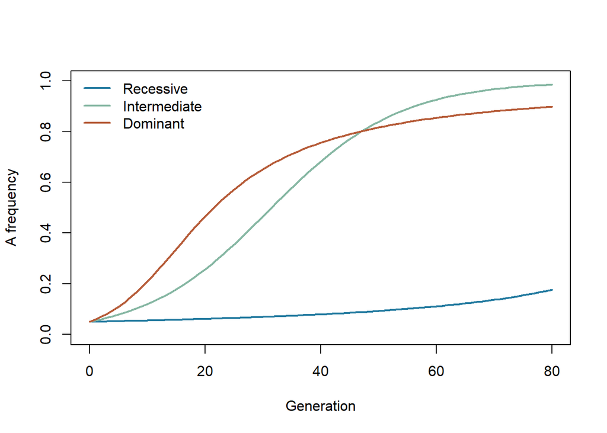

Figure 1: Deterministic selection trajectories from A frequency 0.05 at three fitness-dominance assumptions.

```r
matplot(0:80,trajectories,type="l",lty=1,lwd=2,ylim=c(0,1),
        col=c("#247BA0","#86B7A3","#B65C39"),
        xlab="Generation",ylab="A frequency")
legend("topleft",colnames(trajectories),lty=1,lwd=2,
       col=c("#247BA0","#86B7A3","#B65C39"),bty="n")
```

**Question 2.** Why can a rare beneficial recessive allele increase slowly?

**Suggested answer**

Most of its copies occur in heterozygotes when it is rare. Under the recessive fitness model those heterozygotes have no advantage, and advantageous AA homozygotes are uncommon. Conversely, near fixation a dominant beneficial allele can leave the alternative allele hidden in equally fit heterozygotes, slowing its removal.

## 3. Heterozygote advantage can maintain a polymorphism

Suppose $w_{AA}=1-s$, $w_{Aa}=1$, $w_{aa}=1-t$, with $s,t>0$. The interior equilibrium is

$$p^*=\frac{t}{s+t}.$$

Both alleles can increase when rare because heterozygotes exceed either homozygote in fitness. This is one explicit balancing-selection model, not a claim that every polymorphism is maintained by selection.

**Show R code**

```r
s_loss <- .2
t_loss <- .4
balanced_fitness <- c(AA=1-s_loss,Aa=1,aa=1-t_loss)
p_star <- t_loss/(s_loss+t_loss)
starts <- c(.1,.9)
balanced_paths <- vapply(starts,function(p) {
  selection_trajectory(p,balanced_fitness,60)
},numeric(61))
stopifnot(abs(selection_step(p_star,balanced_fitness)$p_next-p_star)<1e-12,
          selection_step(.1,balanced_fitness)$p_next>.1,
          selection_step(.9,balanced_fitness)$p_next<.9)
p_star
```

```
[1] 0.6666667
```

**Show R code**

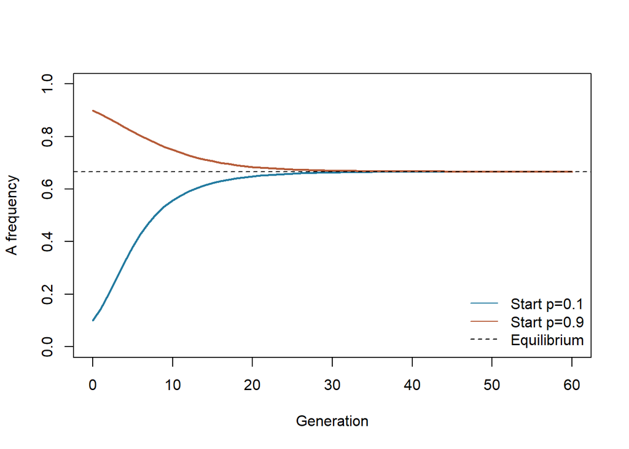

Figure 2: Two deterministic trajectories approaching the heterozygote-advantage equilibrium under supplied fitnesses.

```r
matplot(0:60,balanced_paths,type="l",lty=1,lwd=2,ylim=c(0,1),
        col=c("#247BA0","#B65C39"),xlab="Generation",ylab="A frequency")
abline(h=p_star,lty=2)
legend("bottomright",c("Start p=0.1","Start p=0.9","Equilibrium"),
       col=c("#247BA0","#B65C39","black"),lty=c(1,1,2),bty="n")
```

**Question 3.** Does this deterministic equilibrium guarantee that both alleles persist in a finite population?

**Suggested answer**

No. Drift can still reach loss or fixation. Balancing selection changes the transition probabilities but does not create a missing allele when mutation and migration are absent. The deterministic model and finite-population model answer different questions.

## 4. Combine selection with finite allele-copy sampling

Use the selected-pool frequency as the probability of sampling $2N$ copies for the next generation:

$$K_{t+1}\mid p_t\sim\operatorname{Binomial}(2N,p_{selected}(p_t)).$$

This is a specified one-locus selection-plus-drift model. It does not simulate sex-specific mating, individual family sizes, chromosome recombination or breeding programme constraints.

**Show R code**

```r
selected_drift_trajectory <- function(N,p0,fitness,generations) {
  stopifnot(N>=1,N==as.integer(N),generations>=0,
            generations==as.integer(generations))
  p <- numeric(generations+1L)
  p[1] <- p0
  for(t in seq_len(generations)) {
    p_selected <- selection_step(p[t],fitness)$p_next
    p[t+1L] <- rbinom(1,2*N,p_selected)/(2*N)
  }
  p
}
set.seed(20261009)
N <- 50L
w <- fitness_models$Intermediate
selected_paths <- replicate(20,selected_drift_trajectory(N,.05,w,60))
deterministic <- selection_trajectory(.05,w,60)
stopifnot(all(selected_paths>=0 & selected_paths<=1))
```

**Show R code**

```
     A_lost     A_fixed segregating
          8           6           6
```

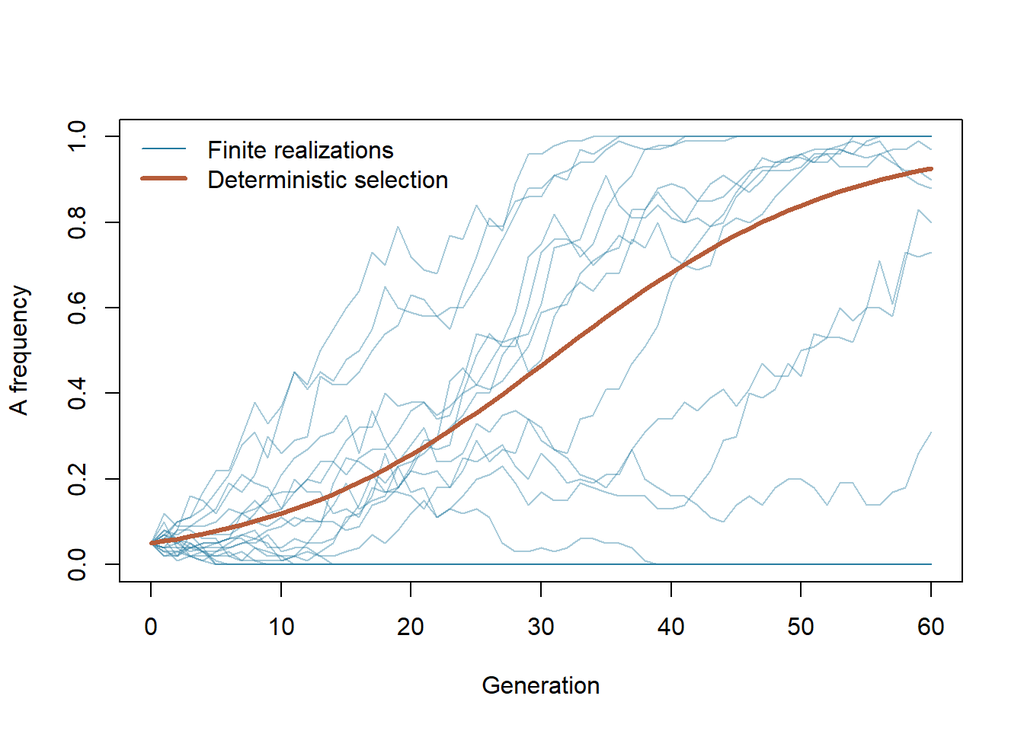

Figure 3: Twenty seeded selection-plus-drift trajectories and the deterministic selection path; the deterministic line is not the exact mean of the stochastic model.

```r
matplot(0:60,selected_paths,type="l",lty=1,ylim=c(0,1),
        col=adjustcolor("#247BA0",alpha.f=.4),
        xlab="Generation",ylab="A frequency")
lines(0:60,deterministic,col="#B65C39",lwd=3)
legend("topleft",c("Finite realizations","Deterministic selection"),
       col=c("#247BA0","#B65C39"),lty=1,lwd=c(1,3),bty="n")
final <- selected_paths[nrow(selected_paths),]
c(A_lost=sum(final==0),A_fixed=sum(final==1),
  segregating=sum(final>0 & final<1))
```

Conditional mean frequency is $p_{selected}(p_t)$. Selection is generally nonlinear, so averaging it over a random $p_t$ is not the same as applying it to the mean frequency. The deterministic line is therefore a useful comparison, not automatically the expected stochastic trajectory. The 20-run outcomes illustrate possible fates; they are not precise fixation-probability estimates.

## Exercises

1. Set every fitness to the same positive value. What happens to the deterministic frequency and the stochastic model?
2. Reverse allele labels and swap the homozygote fitnesses. Verify the next A frequency becomes the complement.
3. Use $w_{AA}=0.7,w_{Aa}=1,w_{aa}=0.9$. Calculate the balancing equilibrium.
4. Explain why the beneficial allele can disappear in the finite runs and why selection cannot restore it at frequency zero.

**Suggested solutions**

**Show R code**

```r
selection_step(.4,c(AA=2,Aa=2,aa=2))$p_next
```

```
[1] 0.4
```

**Show R code**

```r
reversed_fitness <- setNames(unname(fitness[c("aa","Aa","AA")]),
                             c("AA","Aa","aa"))
stopifnot(abs(selection_step(.7,reversed_fitness)$p_next-
               (1-selection_step(.3,fitness)$p_next))<1e-12)
example_equilibrium <- .1/(.3+.1)
stopifnot(abs(selection_step(example_equilibrium,c(AA=.7,Aa=1,aa=.9))$p_next-
               example_equilibrium)<1e-12)
example_equilibrium
```

```
[1] 0.25
```

Equal fitnesses leave deterministic frequency unchanged and reduce the stochastic model to neutral drift. The balancing equilibrium is 0.25 under those specified fitnesses. Finite sampling can draw zero A copies even after selection; without mutation or migration, there are then no A copies for selection to favor.

## App and package connections

The existing selection Shiny app is available for optional local exploration with its existing dependencies. This practical does not change or qualify that app, and the simple one-locus model does not establish a selective sweep at linked loci.

`gpop` owns deterministic population expectations; biological simulation belongs in `gsim`; breeding objectives, selection policy and programme design belong in `gsel`. Natural-selection fitness weights are not automatically economic weights or estimated breeding values. These teaching calculations add no scientific package APIs.